# Innlevering uke 10: fylogeni

Ane Kleiven

2025-04-07

# Last inn aktuelle R-pakker

```r
library(tidyverse)
library(ape)
library(microseq)
library(msa)
```

# 2 Fylogenetiske trær med diskrete metoder

## 2.1 Data

*msa fra mitokondrielt DNA med metoden ‘Muscle’:*

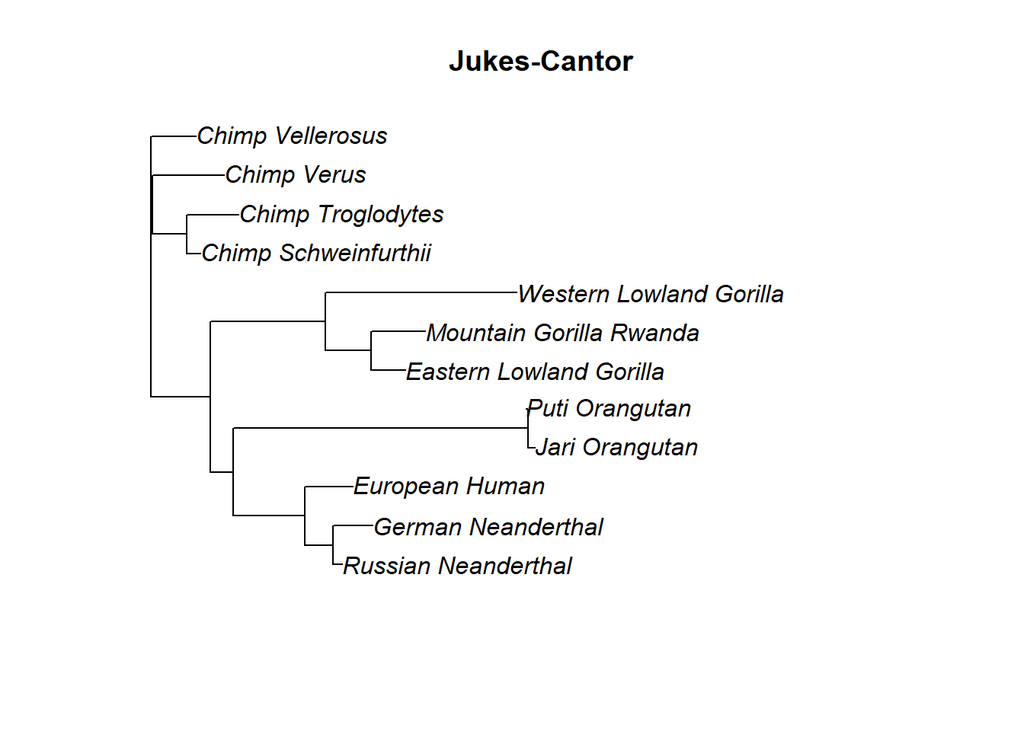

```r
# lag msa
mtDNA.ss <- readDNAStringSet("data/primates_mtDNA.fasta.txt")
mtDNA.msa <- msa(mtDNA.ss, method = "Muscle")

# konverter til DNAbin format
msa_to_DNAbin <- msaConvert(mtDNA.msa, type = "ape::DNAbin")

# beregn avstander med Jukes Cantor
d.jc <- dist.dna(msa_to_DNAbin, model = "JC69")

# plot treet med neighbour joining
nj.JC69 <- bionj(d.jc)
plot(nj.JC69, main = "Jukes-Cantor")
```

## 2.2 Maximum parsimony tre i R

*installèr R-pakken phangorn*

```r
library(phangorn)
```

```r
primates.pdt <- msa::msaConvert(mtDNA.msa, type = "phangorn::phyDat")
parsimony.score <- parsimony(nj.JC69, primates.pdt)
```

**Kopier koden og kjør. Hvor liten parsimony-score får du for dette treet og med denne sammenstillingen?**

```r
cat('Parsimony-scoren er:' , parsimony.score)
```

```
## Parsimony-scoren er: 333
```

**Er det mulig å finne et alternativt tre som gir en lavere score? En funksjon for å optimere tre-topologien er optim.parsimony():**

```r
tre.mp <- optim.parsimony(nj.JC69, primates.pdt)
```

```
## Final p-score 331 after  1 nni operations
```

```r
parsimony.score.opt <- parsimony(tre.mp, primates.pdt)
```

Scoren ble 2 poeng lavere enn den forrige, altså ikke så stor forbedring.

Treet plottet:

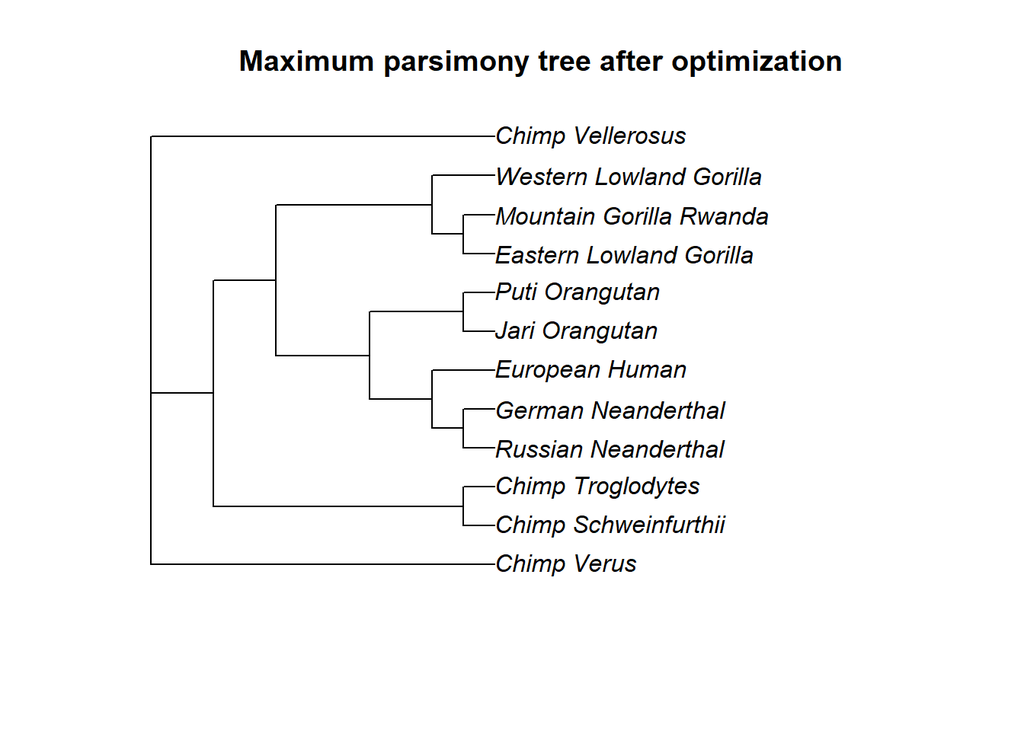

```r
plot(tre.mp, main = "Maximum parsimony tree after optimization")
```

Etter optimering har flere av avstandene i treet blitt endret. Vi kan også se at ‘Chimp Verus’ ikke lenger er i nærheten av de andre sjimpansene.

**en annen måte å optimere treet på:**

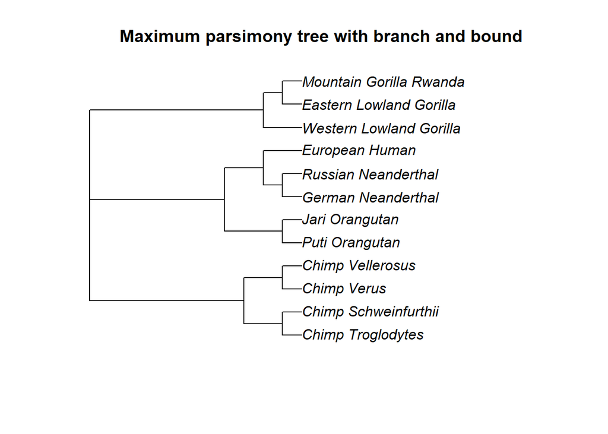

```r
bab.obj <- bab(primates.pdt)
parsimony.score.bab <- parsimony(bab.obj[[1]], primates.pdt)

plot(bab.obj[[1]], main = "Maximum parsimony tree with branch and bound")
```

**Blir scoren bedre? Lag et plot at treet, som ligger i bab.obj[[1]]. Er treet annerledes enn de over?**

Scoren for treet med ‘bab’ blir lik som den forrige optimeringen, men treet ser mer riktig ut mtp på de ulike artene i treet.

## 2.3 Maximum likelihood tre

**Hva er log likelihood for treet du fikk med neighbour joining?**

```r
pml.obj.nj <- pml(nj.JC69, data = primates.pdt)
cat('Log-likelihood scoren for treet er:', pml.obj.nj$logLik)
```

```
## Log-likelihood scoren for treet er: -2175.312
```

**Søk etter det optimale treet:**

```r
pml.obj <- optim.pml(pml.obj.nj, model = "JC", optNni = T)
```

```
## optimize edge weights:  -2175.312 --> -2165.899
## optimize edge weights:  -2165.899 --> -2165.899
## optimize topology:  -2165.899 --> -2162.689  NNI moves:  1
## optimize edge weights:  -2162.689 --> -2162.689
## optimize topology:  -2162.689 --> -2162.689  NNI moves:  0
```

```r
cat('Log-likelihood scoren for treet etter optimalisering er:', pml.obj$logLik)
```

```
## Log-likelihood scoren for treet etter optimalisering er: -2162.689
```

**Plot av treet:**

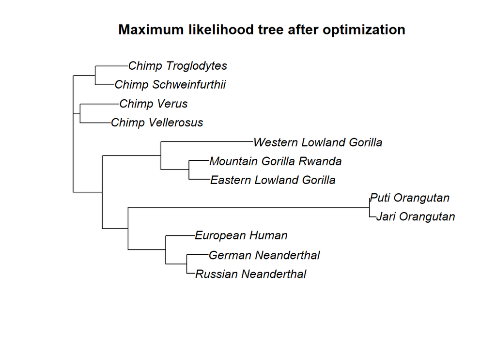

```r
plot(pml.obj$tree, main = "Maximum likelihood tree after optimization")
```

# 3 ML-tre fra IQ-TREE online

**lagre msa som fastafil**

```r
ape::write.FASTA(msa_to_DNAbin, file = "primates_muscle.msa")
```

**Les den inn i R og plott treet. Ble det likt det vi fikk i R?**

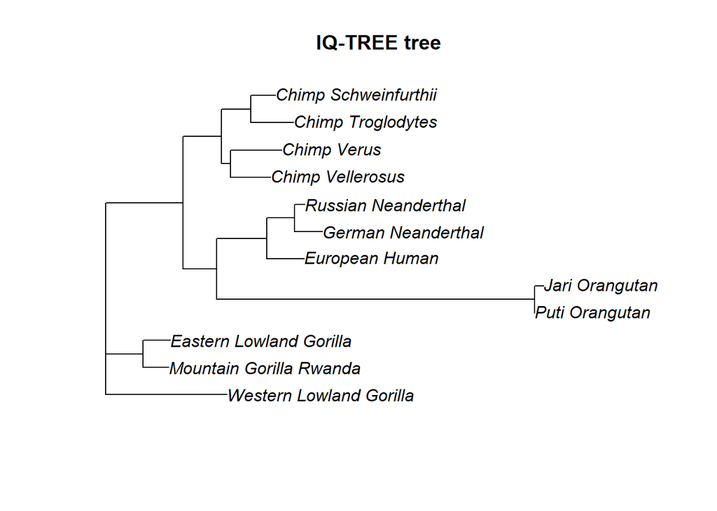

```r
treefile <- read.tree('data/primates_muscle.msa.treefile')
plot(treefile, main = "IQ-TREE tree")
```

Treet fra IQ-TREE ble nokså likt det vi laget i R. Neandertalkladen har byttet plass med gorillakladen.

# R-lab

## 4.1 Plotte trær med ggtree

```r
BiocManager::install("ggtree")
library(ggtree)
```

```r
msa <- read.dna("primates_muscle.msa", format = "fasta")
d.JC69 <- dist.dna(msa, model = "JC69")
tre.nj <- bionj(d.JC69)
```

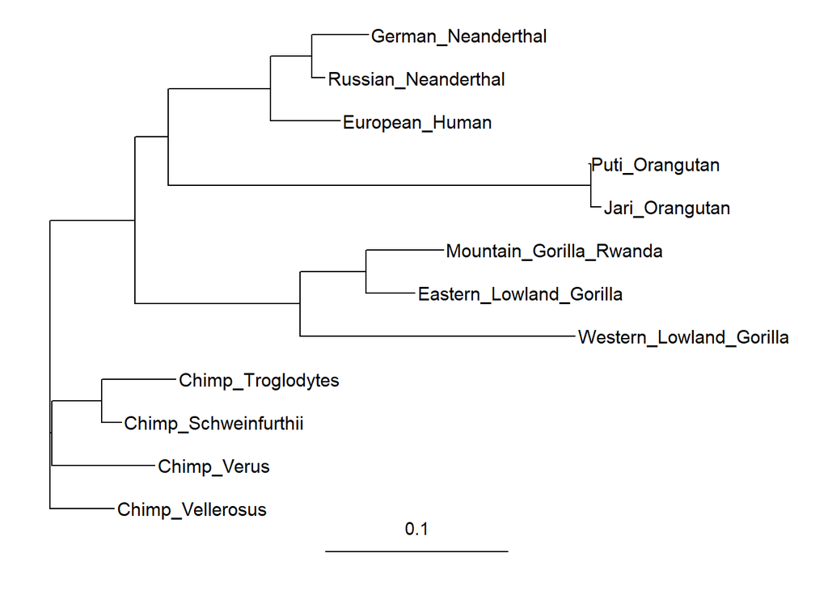

```r
mitt.gg.tre <- ggtree(tre.nj, layout = "rect") +
  geom_tiplab(size = 4) +
  geom_treescale(width = 0.10) +
  ggplot2::xlim(0, 0.4)
print(mitt.gg.tre)
```

```r
data.tbl <- readFasta("primates_muscle.msa") %>%
  mutate(Type = case_when(
    str_detect(Header, "Gorilla") ~ "Gorilla",
    str_detect(Header, "Orangutan") ~ "Orangutan",
    str_detect(Header, "Chimp") ~ "Chimpanzee",
    .default = "Human"
  ))
```

**Fargelegg grenene i treet:**

*Legg merke til hvordan vi bruker operatoren %<+% for å ‘lime’ tabellen data.tbl til ggtree-objektet.*

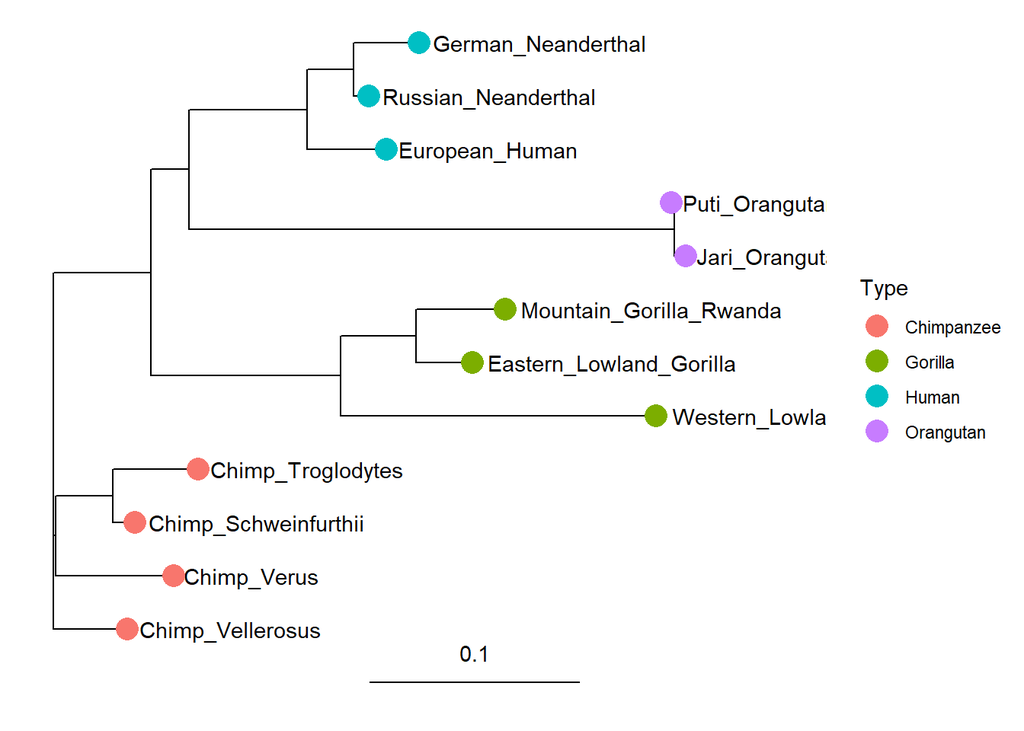

```r
mitt.gg.tree <- ggtree(tre.nj) %<+% data.tbl +
  geom_tiplab(hjust = -0.05) +
  geom_tippoint(aes(color = Type), size = 5) +
  geom_treescale(width = 0.10) +
  theme(legend.position = "right") +
  ggplot2::xlim(0, 0.35)

mitt.gg.tree
```

**Fargelegg også tekstene i treet etter kolonnen Type. Hint: Geomet geom_tiplab() skjønner også estetikken color slik som geom_tippoint().**

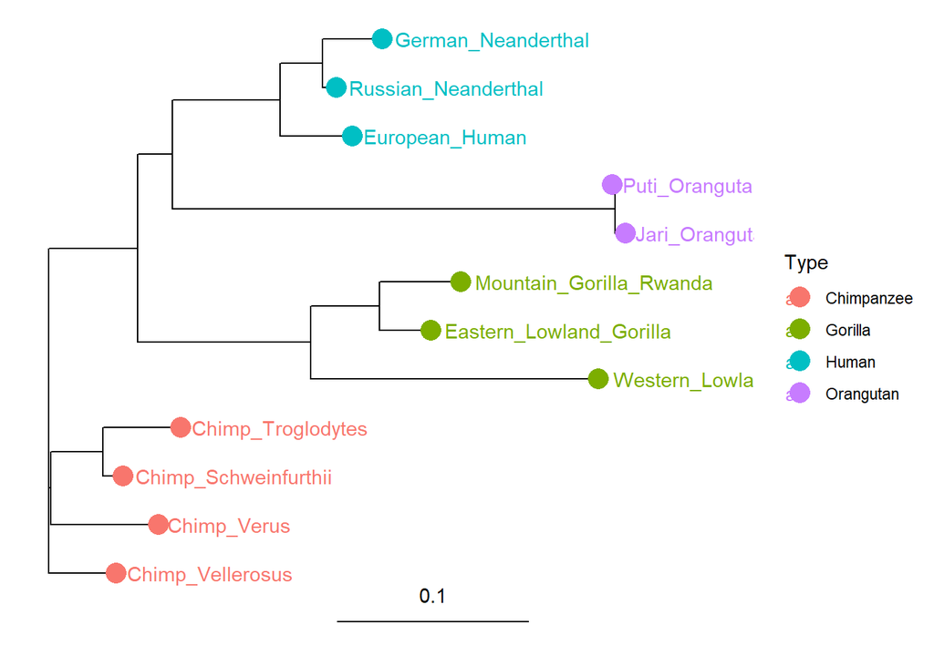

```r
mitt.gg.tree <- ggtree(tre.nj) %<+% data.tbl +
  geom_tiplab(hjust = -0.05, aes(color = Type)) +
  geom_tippoint(aes(color = Type), size = 5) +
  geom_treescale(width = 0.10) +
  theme(legend.position = "right") +
  ggplot2::xlim(0, 0.35)
mitt.gg.tree
```

## 4.2 Mer om `logicals`

```r
g <- TRUE
```

```r
a <- 4
b <- (a < 5)
b
```

```
## [1] TRUE
```

```r
ord <- c("Nei","Nej","No","Njet","Nein")
er.engelsk <- (ord == "No")
```

```r
idx <- which(er.engelsk)
print(idx)
```

```
## [1] 3
```

## 4.3 Eksempel - bruk av logicals

```r
data <- read.dna("data/samle_fil_16S_msa.fasta.txt", format = "fasta")
p.distanser <- dist.dna(data, model = "raw")
```

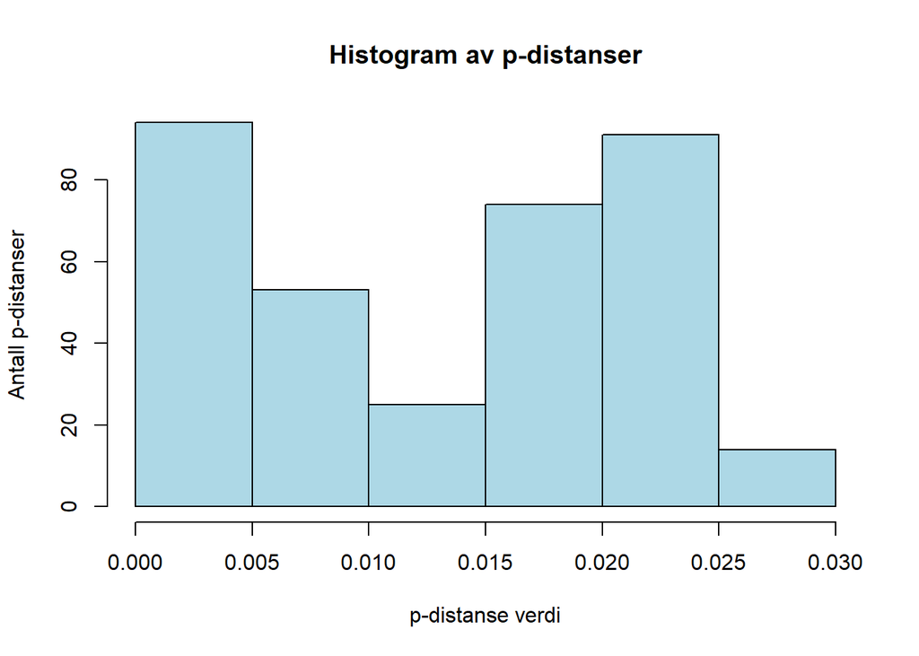

```r
hist(p.distanser, col = "lightblue", xlab = "p-distanse verdi",
     ylab = "Antall p-distanser", main = "Histogram av p-distanser")
```

### 4.3.1 Alle p-distanser fra samme art

```r
p.matrise <- as.matrix(p.distanser)
print(p.matrise[16:17,16:17])
```

```
##                      persica_9_kopi1 hispaniensis_1_kopi1
## persica_9_kopi1           0.00000000           0.01264045
## hispaniensis_1_kopi1      0.01264045           0.00000000
```

```r
print(rownames(p.matrise))
```

```
##  [1] "noatunensis_2_kopi1"   "noatunensis_3_kopi1"   "noatunensis_4_kopi1"
##  [4] "noatunensis_5_kopi1"   "noatunensis_6_kopi1"   "noatunensis_7_kopi1"
##  [7] "noatunensis_8_kopi1"   "philomiragia_13_kopi1" "philomiragia_11_kopi1"
## [10] "philomiragia_12_kopi1" "philomiragia_17_kopi1" "philomiragia_15_kopi1"
## [13] "philomiragia_16_kopi1" "philomiragia_14_kopi1" "persica_10_kopi1"
## [16] "persica_9_kopi1"       "hispaniensis_1_kopi1"  "tularensis_24_kopi1"
## [19] "tularensis_25_kopi1"   "tularensis_18_kopi1"   "tularensis_20_kopi1"
## [22] "tularensis_21_kopi1"   "tularensis_22_kopi1"   "tularensis_23_kopi1"
## [25] "tularensis_26_kopi1"   "tularensis_27_kopi1"   "tularensis_19_kopi1"
```

```r
rad.navn <- rownames(p.matrise)
art <- word(rad.navn, 1, 1, sep = "_")
```

### 4.3.2 Vi bruker logiske vektorer

```r
er.tularensis <- (art == "tularensis")
idx <- which(er.tularensis)
idx
```

```
##  [1] 18 19 20 21 22 23 24 25 26 27
```

```r
p.matrise.tularensis <- p.matrise[idx,idx]
```

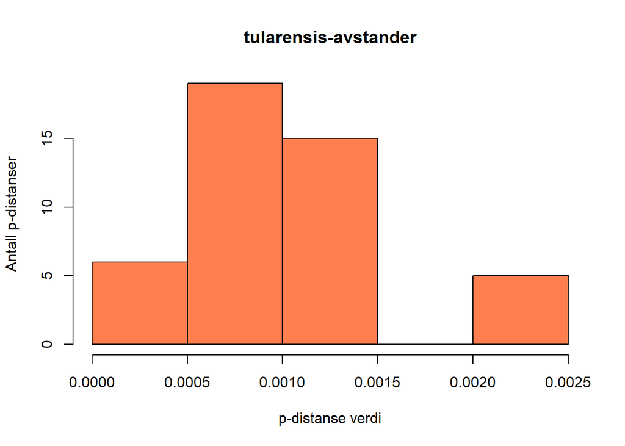

```r
p.distanser.tularensis <- as.dist(p.matrise.tularensis)
hist(p.distanser.tularensis, col = "coral", main = "tularensis-avstander",
     xlab = "p-distanse verdi", ylab = "Antall p-distanser")
```

**Vi kunne også ha hentet ut disse tularensis-avstandene ved å bruke funksjonen str_which() som likner mye på str_detect() som vi har sett før. Hvordan ville du ha gjort det? Vis kode og lag et histogram av avstandene med ggplot().**

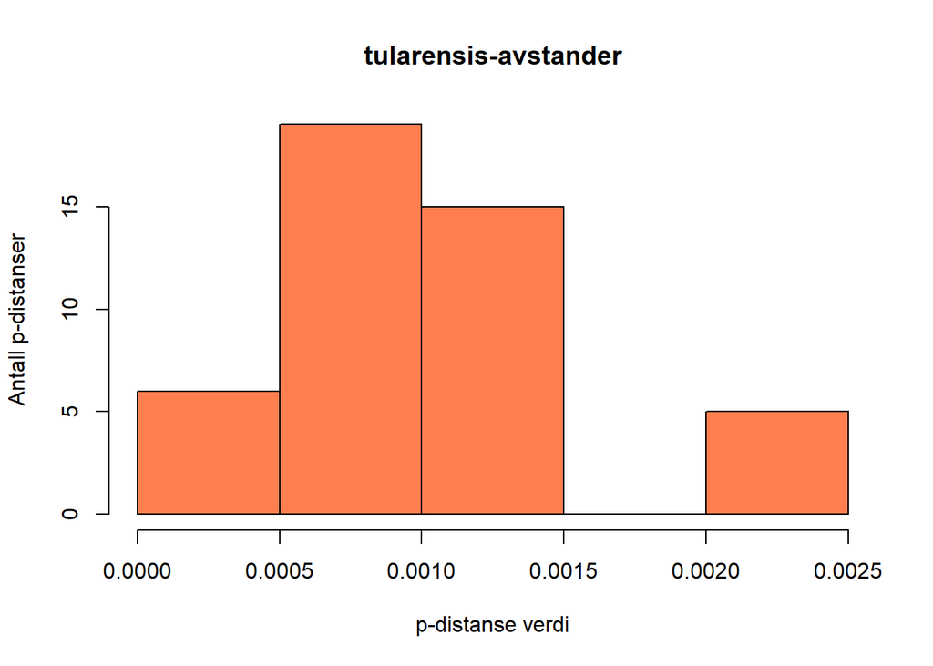

```r
p.dist.tularensis <- as.dist(p.matrise[str_which(rownames(p.matrise), "tularensis"),
                            str_which(rownames(p.matrise), "tularensis")])

hist(p.dist.tularensis, col = "coral", main = "tularensis-avstander",
     xlab = "p-distanse verdi", ylab = "Antall p-distanser")
```